# Global Suicide Data Analysis

## In this project, we will explore global suicide data between 1985 and 2016. We will study and quantify the relations between suicide and its factors such as age, gender, and more.

### Analysis:

#### Step 1 - Load in the data

For this project, we will be using the following dataset: https://www.kaggle.com/datasets/russellyates88/suicide-rates-overview-1985-to-2016?resource=download. To download the dataset, press the black "Download" button on the top right of the webpage (you may need to make a Kaggle account before downloading the dataset). After pressing Download, you should have access to a file named "master.csv". For clarity purposes, I renamed the file "globalsuicidedata.csv" locally. A CSV file (comma-separated values file) is a text file in which data is organized in an tabular format. Read more about you can open CSVs file here: https://www.howtogeek.com/348960/what-is-a-csv-file-and-how-do-i-open-it/. While the CSV file's data is already arranged in a table format, we need to transform the CSV into a python datastructure on which we can easily perform numerical and organizational operations on the rows and columns (such as sorting, adding rows together, etc.) This will come in hand for when we want to perform statistical tests later. Python provides a datastructure for this, dataframes, with its library pandas (python data analysis library).

Let's import the Pandas library and view what our data looks like (what columns do we have? what about rows? how are columns and rows organized?)

```python
import pandas as pd # Import the pandas library
suicide_df = pd.read_csv("globalsuicidedata.csv")
suicide_df.head(10) # Show me the first 10 rows of data.
```

|  | country | year | sex | age | suicides_no | population | suicides/100k pop | country-year | HDI for year | gdp_for_year ($) | gdp_per_capita ($) | generation |
| --- | --- | --- | --- | --- | --- | --- | --- | --- | --- | --- | --- | --- |
| 0 | Albania | 1987 | male | 15-24 years | 21 | 312900 | 6.71 | Albania1987 | NaN | 2,156,624,900 | 796 | Generation X |
| 1 | Albania | 1987 | male | 35-54 years | 16 | 308000 | 5.19 | Albania1987 | NaN | 2,156,624,900 | 796 | Silent |
| 2 | Albania | 1987 | female | 15-24 years | 14 | 289700 | 4.83 | Albania1987 | NaN | 2,156,624,900 | 796 | Generation X |
| 3 | Albania | 1987 | male | 75+ years | 1 | 21800 | 4.59 | Albania1987 | NaN | 2,156,624,900 | 796 | G.I. Generation |
| 4 | Albania | 1987 | male | 25-34 years | 9 | 274300 | 3.28 | Albania1987 | NaN | 2,156,624,900 | 796 | Boomers |
| 5 | Albania | 1987 | female | 75+ years | 1 | 35600 | 2.81 | Albania1987 | NaN | 2,156,624,900 | 796 | G.I. Generation |
| 6 | Albania | 1987 | female | 35-54 years | 6 | 278800 | 2.15 | Albania1987 | NaN | 2,156,624,900 | 796 | Silent |
| 7 | Albania | 1987 | female | 25-34 years | 4 | 257200 | 1.56 | Albania1987 | NaN | 2,156,624,900 | 796 | Boomers |
| 8 | Albania | 1987 | male | 55-74 years | 1 | 137500 | 0.73 | Albania1987 | NaN | 2,156,624,900 | 796 | G.I. Generation |
| 9 | Albania | 1987 | female | 5-14 years | 0 | 311000 | 0.00 | Albania1987 | NaN | 2,156,624,900 | 796 | Generation X |

Here, we can see that we have columns such as country, year, gender, the age group of the person who passed away, and other statistics. We also see a column which contains a lot of NaN's. NaN means that the cell is missing data. We can clean up our data by removing that column, because in this project, we won't really be working with a column that has missing entries. We also will not be working with the Generation album, so I will delete that column.

```python
# Delete the column. We have to say axis = 1 to delete columns, because the function deletes row entries by default.
suicide_df = suicide_df.drop(["HDI for year"],axis=1)
suicide_df = suicide_df.drop(["generation"],axis=1)
suicide_df.head(10) # Show me the first 10 rows of data after deleting the HDI column.
```

|  | country | year | sex | age | suicides_no | population | suicides/100k pop | country-year | gdp_for_year ($) | gdp_per_capita ($) |
| --- | --- | --- | --- | --- | --- | --- | --- | --- | --- | --- |
| 0 | Albania | 1987 | male | 15-24 years | 21 | 312900 | 6.71 | Albania1987 | 2,156,624,900 | 796 |
| 1 | Albania | 1987 | male | 35-54 years | 16 | 308000 | 5.19 | Albania1987 | 2,156,624,900 | 796 |
| 2 | Albania | 1987 | female | 15-24 years | 14 | 289700 | 4.83 | Albania1987 | 2,156,624,900 | 796 |
| 3 | Albania | 1987 | male | 75+ years | 1 | 21800 | 4.59 | Albania1987 | 2,156,624,900 | 796 |
| 4 | Albania | 1987 | male | 25-34 years | 9 | 274300 | 3.28 | Albania1987 | 2,156,624,900 | 796 |
| 5 | Albania | 1987 | female | 75+ years | 1 | 35600 | 2.81 | Albania1987 | 2,156,624,900 | 796 |
| 6 | Albania | 1987 | female | 35-54 years | 6 | 278800 | 2.15 | Albania1987 | 2,156,624,900 | 796 |
| 7 | Albania | 1987 | female | 25-34 years | 4 | 257200 | 1.56 | Albania1987 | 2,156,624,900 | 796 |
| 8 | Albania | 1987 | male | 55-74 years | 1 | 137500 | 0.73 | Albania1987 | 2,156,624,900 | 796 |
| 9 | Albania | 1987 | female | 5-14 years | 0 | 311000 | 0.00 | Albania1987 | 2,156,624,900 | 796 |

Perfect! We can begin analysis now.

#### Step 2 - Analysis Part 1: Year vs. Suicide Rate

In this section, we will explore how suicide rates have changed over time. We want to study if suicide rate has changed over time, so that if we observe a change, we can ask ourselves the following questions:

- how can we visualize suicide numbers over time? how much do suicide rates change every year?
- was there a year with peak suicide numbers? What happened in this year specifically that may have caused this?

In order to visualize suicide numbers over time, we can make a scatter plot of suicide numbers across time. We will use the suicides/100k population column specifically, so that we can standardize comparison between bigger and smaller countries. There are many ways you can make a scatter plot in python, such as with matplotlib or seaborn (these are two data visualization libraries in python). In this tutorial, we will use matplotlib, but I encourage you to also explore how to make a scatter plot in seaborn (https://seaborn.pydata.org/generated/seaborn.scatterplot.html). Matplotlib and seaborn have their own strengths, such as Matplotlib being compatible with more APIs and seaborn containing more advanced graphical features. For something basic like a scatter plot though, it doesn't matter very much what library you decide to use.

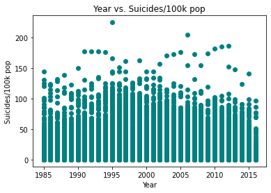

```python
#import matplotlib, name it something shorter (plt) for our convenience
import matplotlib.pyplot as plt
# scatter function takes in our x axis and y axis and optionally even the color of our graph
plt.scatter(suicide_df['year'],suicide_df['suicides/100k pop'],color = "teal")
# naming the axis labels
plt.title("Year vs. Suicides/100k pop")
plt.xlabel("Year")
plt.ylabel("Suicides/100k pop")
#display the graph
plt.show()
```

From this graph, we can see that over time, most countries's suicide rate was below about 150 for every 100,000 people. It is important to note though that many of these rates that did jump over 150 occured after 1990. Specifically, there are many rates closer to 200 between 2005 and 2012. What could've caused this? One hypothesis is that the Great Recession (which occured in 2007 to 2009) increased the rate of suicide as unemployment and poor financial circumstances often lead to stress which is a major factor of suicide. One thing to also note is that there does not seem to be a linear increase between the years. The bottom of the vertical bars tends to be constant, with occasional fluctuations on the top of the bars. Before we look more into this, let's find a clearer graph that shows the distribution and statistics of suicide rate per year.

A great way to do this is to plot a violin plot for each year. A violin plot will allow us to easily visualize the distribution shape of the data for each year, essentially providing us with per-year summaries of our data. While we could also plot a box plot to get summary statistics for each year, violin plots give even more information by also taking into account the density of the data point. Matplotlib provides an easy way to make this violin plot:

In order to plot our violin plot, we will pass two sets of data into the violin plot function. The data will take this form... year_1 => [suiciderate1, suiciderate2, suiciderate3...] year_2 => [suiciderate3,suiciderate4,suiciderate5...] . . . year_n => [suicideraten,suicideraten+1,suicideraten+2...] and we will pass in a list of years and their corresponding lists of suicide rates.

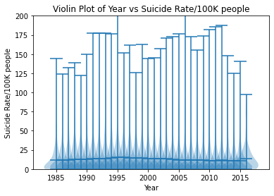

```python
years = [] # a list of years that we can use for the plot
dict_year_to_suiciderate = dict() # a dictionary that we can use to pair our years to a list of suicide rates
suiciderates = [] # a list of lists of suicide rates that we can use for the plot

for row in suicide_df.itertuples(index=False): # go through each row of the dataframe, ignore the leftmost column known as index
    year = row[1]
    s_rate = row[6]
    if year not in dict_year_to_suiciderate.keys(): # update the dictionary, matching each year to a list of suicide rates that happened in that year
        dict_year_to_suiciderate[year] = [s_rate]
    else:
        dict_year_to_suiciderate[year].append(s_rate)

for yr in dict_year_to_suiciderate.keys(): # make the final lists that we will pass into plot
    years.append(yr) # a list of years
    suiciderates.append(dict_year_to_suiciderate[yr]) # a list of each year's suicide rates (which is also a list)

# This is how you can create a violin plot.
fig, ax = plt.subplots()
ax.violinplot(suiciderates,years,widths=4,showmeans=True) # suicide rates = y axis, years = x axis
ax.set_xlabel("Year") # label our plot
ax.set_ylabel("Suicide Rate/100K people")
ax.set_ylim(0, 200,10)
ax.set_title("Violin Plot of Year vs Suicide Rate/100K people")
fig.savefig("violin.png")
```

After creating the violin plot, we can observe the following.

In every year, we are unable to see a round violin shape. In other words, there's no curves, indicating there are no peaks in the suicide rate (no normal distribution). Why may this be? This could be because when there is a normal distribution, we definitely observe that there is a peak (meaning one datapoint that occurs in high frequency). This normal distribution may occur because it is expected/normal to have a certain datapoint peak. In this case, there's no "normal" or "center" suicide rate that all the other values surround.

After some research (quick read: https://en.wikipedia.org/wiki/Early_1990s_recession#:~:text=The%20early%201990s%20recession%20describes,Bush.), I was able to find that the early 1990's was also a short period of economic downfall for many people globally. This could be why suicide rates dramatically increased during this time. However, one rebuttal to this is that 2010-2015 is also known as a time of economic struggle (because many people remained unemployed after the recession), but suicide rates dramatically decreased between years.

While the graph we generated is somewhat useful, let's also try grouping the years together into different chunks, so we can see if we can find out anything else about the suicide rate distributions. Why is this neccesary? In statistical analysis, it is really important to think about the context we are working in. Typically, when people look at history, they think of different eras or periods of time (for example, instead of thinking about 2007, 2008, and 2009 individually, people often think about the overall Great Recession era which happened during those years). That's why it is also important for us to look at our data in the same way. Let's compare different eras together by assembling a new dictionary using the same techniques as earlier.

```
Note that on the x axis, 1985 means 1985-1990, 1990 means 1990-1995, and so on.
```

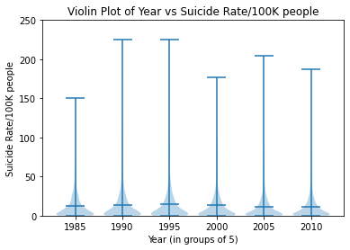

```python
years = [] # a list of years that we can use for the plot
dict_year_to_suiciderate = dict() # a dictionary that we can use to pair our years to a list of suicide rates
suiciderates = [] # a list of lists of suicide rates that we can use for the plot

# This is the exact same algorithm that we used previously. The only difference is that this time, the keys are not individual years. Instead, they are groups of years. As a result,
# the key will be a string specifying the group of years, rather than an integer representing the year. However, note that the violin plot function will not accept our
# final years list if it has strings in it, so we will convert the string into an integer soon.
for row in suicide_df.itertuples(index=False): # go through each row of the dataframe, ignore the leftmost column known as index
    year = row[1]
    s_rate = row[6]
    if year >= 1985 and year <=1990:
        year_key = "1985-1990" #setting the string based on the range we are in
        if year_key not in dict_year_to_suiciderate.keys(): # update the dictionary, matching each year to a list of suicide rates that happened in that year
            dict_year_to_suiciderate[year_key] = [s_rate]
        else:
            dict_year_to_suiciderate[year_key].append(s_rate)
    if year >= 1990 and year <=1995:
        year_key = "1990-1995" #setting the string based on the range we are in
        if year_key not in dict_year_to_suiciderate.keys(): # update the dictionary, matching each year to a list of suicide rates that happened in that year
            dict_year_to_suiciderate[year_key] = [s_rate]
        else:
            dict_year_to_suiciderate[year_key].append(s_rate)
    if year >= 1995 and year <=2000:
        year_key = "1995-2000" #setting the string based on the range we are in
        if year_key not in dict_year_to_suiciderate.keys(): # update the dictionary, matching each year to a list of suicide rates that happened in that year
            dict_year_to_suiciderate[year_key] = [s_rate]
        else:
            dict_year_to_suiciderate[year_key].append(s_rate)
    if year >= 2000 and year <=2005:
        year_key = "2000-2005" #setting the string based on the range we are in
        if year_key not in dict_year_to_suiciderate.keys(): # update the dictionary, matching each year to a list of suicide rates that happened in that year
            dict_year_to_suiciderate[year_key] = [s_rate]
        else:
            dict_year_to_suiciderate[year_key].append(s_rate)
    if year >= 2005 and year <=2010:
        year_key = "2005-2010" #setting the string based on the range we are in
        if year_key not in dict_year_to_suiciderate.keys(): # update the dictionary, matching each year to a list of suicide rates that happened in that year
            dict_year_to_suiciderate[year_key] = [s_rate]
        else:
            dict_year_to_suiciderate[year_key].append(s_rate)
    if year >=2010 and year <=2016:
        year_key = "2010-2016" #setting the string based on the range we are in
        if year_key not in dict_year_to_suiciderate.keys(): # update the dictionary, matching each year to a list of suicide rates that happened in that year
            dict_year_to_suiciderate[year_key] = [s_rate]
        else:
            dict_year_to_suiciderate[year_key].append(s_rate)
# While we had string key values for our years previously, we need to make sure the years are integers before we feed them into the plot. Let's represent each string
# with the first integer in the range.
for yr in dict_year_to_suiciderate.keys(): # make the final lists that we will pass into plot
    if yr == "1985-1990":
        new_label = 1985
    elif yr == "1990-1995":
        new_label = 1990
    elif yr == "1995-2000":
        new_label = 1995
    elif yr == "2000-2005":
        new_label = 2000
    elif yr == "2005-2010":
        new_label = 2005
    elif yr == "2010-2016":
        new_label = 2010
    years.append(new_label) # a list of years
    suiciderates.append(dict_year_to_suiciderate[yr]) # a list of each year's suicide rates (which is also a list)

# This is how you can create a violin plot. This is the same code as above, but this time, we are plotting 6 different groups only. Notice how
# we have adjusted the plot labels and added a clarification on how to interpret the graph.
fig, ax = plt.subplots()
ax.violinplot(suiciderates,years,widths=4,showmeans=True) # suicide rates = y axis, years = x axis
ax.set_xlabel("Year (in groups of 5)") # label our plot
ax.set_ylabel("Suicide Rate/100K people")
ax.set_ylim(0, 250,10)
ax.set_title("Violin Plot of Year vs Suicide Rate/100K people")
fig.savefig("violin.png")
print ("Note that on the x axis, 1985 means 1985-1990, 1990 means 1990-1995, and so on.")
```

As we can see above, grouping the years together made a major difference in the distribution of the violin plots. For all of the distributions, we can see that the data is right skewed (most of the data leaning to the left). Why does the rate have this shape? Well, we can reasonably assume that suicide rate does not have a normal shape. This is because there isn't exactly a peak, but more like low suicide rates with occasional fluctuations that may result from countries with suicide epidemics. Our goal is to continue studying which demographics these high fluctuations come from.

Some positive insights from this graph:

- Suicide does not seem to increase linearly over time (we can quantify this later using regression!). Look at the top bars of each violin plot, they do not follow any sort of consistent linear increasing or decreasing shape. The bottom bars of the violin plots also stay in the same place.
- 1990-2000 had a relatively high suicide rate compared to the other time ranges.
- Often, peaks of suicide rate were followed with decreases in suicide rate. Why is this? Potentially because of more discussion surrounding mental health after suicide epidemics.
- Suicide rates tends to be on the lower side. Does that mean that most prevention policies currently are mostly effective or that they are being directed to the right crowds most of the time?

By now, we have performed some visual analysis and have formed some conclusions about the relationship between time and suicide rate. It's time to do some quantitive analysis! We are going to fit a linear regression line to our data using Scikit-Learn to see if we can get a better feel for the correlation between time and suicide rate.

What is Scikit-Learn? Scikit-Learn is a machine learning library in Python that allows you to perform data predictions. It is similar to pandas in the sense that it helps with data analysis, but it expands specifically on machine learning tools. For example, it provides built-in classifiers such as KNN and built-in regression tools like SVM regression. You can read more about Scikit-Learn and its tools here: https://www.educative.io/blog/scikit-learn-cheat-sheet-classification-regression-methods. In this tutorial, we will use the basics linear regression classifier.

What can you use instead of Scikit-Learn for regression? There are several other ways you can perform linear regression in python. While Scikit-Learn makes it very easy to implement machine learning, you can also look into the following methods for linear regression.

- Writing from scratch (https://medium.com/geekculture/linear-regression-from-scratch-in-python-without-scikit-learn-a06efe5dedb6)
- Simple regression line (https://dataaspirant.com/simple-linear-regression-python-without-any-machine-learning-libraries/)
- Closed form solution: https://towardsdatascience.com/normal-equation-in-python-the-closed-form-solution-for-linear-regression-13df33f9ad71 However, I think that for the purposes of the tutorial, Scikit-Learn is a perfect way to implement linear regression without writing too much code or worrying about the math behind how linear regression is calculated.

When implementing Linear Regression, we will also use a python library, numpy. Numpy is a powerful python library that works with numerical calculations, matrix manipulation, and matrix operations. In this case, we will need to reshape our x-data before we feed it into the classifier (due to rules of matrix algebra), which can be done easily through numpy. Read more about numpy here: https://numpy.org/doc/stable/user/absolute_beginners.html.

```python
from sklearn.linear_model import LinearRegression  # access Scikit-Learn library
import numpy #import numpy
model = LinearRegression()
xnew = numpy.array(suicide_df["year"]).reshape((-1,1))
ynew = numpy.array(suicide_df["suicides/100k pop"])
model.fit(xnew, ynew)
model = LinearRegression().fit(xnew, ynew)
r_sq = model.score(xnew, ynew)
print(f"Slope: {model.coef_}")
print(f"Intercept: {model.intercept_}")
```

```
Slope: [-0.08740015]
Intercept: 187.72637509128984
```

Interesting! The slope of the regression line is actually negative and small, indicating that there is not a strong linear relationship. The small linear relationship that does exist is very negligible.

From this exploration on how suicide rates have changed over time, we can answer some of the questions we answered earlier.

- how can we visualize suicide numbers over time? how much do suicide rates change every year?
  - Suicide numbers remained pretty consistent over time, with occasional fluctuations. Suicide rates changed about -0.08740015 /100K in the population every year, meaning that there is a very small overall decrease over time. However, between certain different eras, there were increases in suicide rate.
- was there a year with peak suicide numbers? What happened in this year specifically that may have caused this?
  - There seems to be higher suicide rates from 1990-2000 and 2005-2010. Because a recession occured during both of these periods, it is possible that there was a peak due to stress/economic pressures/societal hardship.

#### Step 3 - Analysis Part 2 Age/Gender vs. Suicide Rate

In this section, we are going to explore how age and gender affects suicide rate. We will compare the suicide rate distributions for each age group provided in the data and recognize any groups that are more prone to suicidal thoughts than others. After our analysis, we can ask ourselves the following questions:

- Is there an age in which suicidal thoughts are more prevalent? A certain gender group in which these thougthts are prevalent?
- Why may suicidal thoughts be more prevalent in certain groups/genders?

Before we begin plotting, check out this great video which explains how to format data before passing it into the bar plot function (provided my matplotlib). https://youtu.be/zwSJeIcRFuQ

```python
# First, let's create the dictionaries we need.

dict_1985_1990 = dict()
dict_1990_1995 = dict()
dict_1995_2000 = dict()
dict_2000_2005 = dict()
dict_2005_2010 = dict()
dict_2010_2016 = dict()

# Let's fill the dictionary for each year range with age ranges paired to their suicide rate sums.
for row in suicide_df.itertuples(index=False): # go through each row of the dataframe, ignore the leftmost column known as index
    year = row[1]
    age = row[3]
    s_rate = row[6]
    if year>=1985 and year<=1990:
        if age in dict_1985_1990.keys():
            dict_1985_1990[age] += s_rate
        else:
            dict_1985_1990[age] = s_rate
    if year>=1990 and year<=1995:
        if age in dict_1990_1995.keys():
            dict_1990_1995[age] += s_rate
        else:
            dict_1990_1995[age] = s_rate
    if year>=1995 and year<=2000:
        if age in dict_1995_2000.keys():
            dict_1995_2000[age] += s_rate
        else:
            dict_1995_2000[age] = s_rate
    if year>=2000 and year<=2005:
        if age in dict_2000_2005.keys():
            dict_2000_2005[age] += s_rate
        else:
            dict_2000_2005[age] = s_rate
    if year>=2005 and year<=2010:
        if age in dict_2005_2010.keys():
            dict_2005_2010[age] += s_rate
        else:
            dict_2005_2010[age] = s_rate
    if year>=2010 and year<=2016:
        if age in dict_2010_2016.keys():
            dict_2010_2016[age] += s_rate
        else:
            dict_2010_2016[age] = s_rate

categories = ["5-14 years","25-34 years","35-54 years","55-74 years","75+ years"]
# Now, let's make the lists for 1985+
rates_1985 = []
for i in categories:
    rates_1985.append(dict_1985_1990[i])
# Now, let's make the lists for 1990+
rates_1990 = []
for i in categories:
    rates_1990.append(dict_1990_1995[i])
# Now, let's make the lists for 1995+
rates_1995 = []
for i in categories:
    rates_1995.append(dict_1995_2000[i])
# Now, let's make the lists for 2000+
rates_2000 = []
for i in categories:
    rates_2000.append(dict_2000_2005[i])
# Now, let's make the lists for 2005+
rates_2005 = []
for i in categories:
    rates_2005.append(dict_2005_2010[i])
# Now, let's make the lists for 2010+
rates_2010 = []
for i in categories:
    rates_2010.append(dict_2010_2016[i])
```

```
<BarContainer object of 5 artists>
```

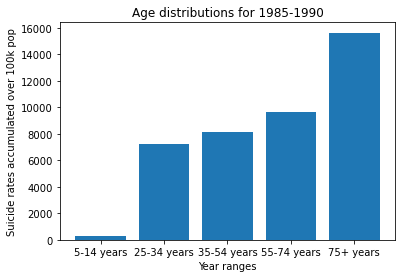

```python
plt.title('Age distributions for 1985-1990')
plt.xlabel("Year ranges")
plt.ylabel("Suicide rates accumulated over 100k pop")
plt.bar(categories,rates_1985)
```

```
<BarContainer object of 5 artists>
```

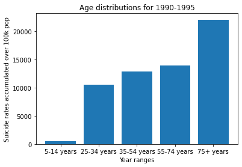

```python
plt.title('Age distributions for 1990-1995')
plt.xlabel("Year ranges")
plt.ylabel("Suicide rates accumulated over 100k pop")
plt.bar(categories,rates_1990)
```

```
<BarContainer object of 5 artists>
```

[figure not shown]

```python
plt.title('Age distributions for 1995-2000')
plt.xlabel("Year ranges")
plt.ylabel("Suicide rates accumulated over 100k pop")
plt.bar(categories,rates_2000)
```

```
<BarContainer object of 5 artists>
```

[figure not shown]

```python
plt.title('Age distributions for 2000-2005')
plt.xlabel("Year ranges")
plt.ylabel("Suicide rates accumulated over 100k pop")
plt.bar(categories,rates_2005)
```

```
<BarContainer object of 5 artists>
```

[figure not shown]

```python
plt.title('Age distributions for 2005-2010')
plt.xlabel("Year ranges")
plt.ylabel("Suicide rates accumulated over 100k pop")
plt.bar(categories,rates_2010)
```

```python
# First, let's create the dictionaries we need.

dict_1985_1990 = dict()
dict_1990_1995 = dict()
dict_1995_2000 = dict()
dict_2000_2005 = dict()
dict_2005_2010 = dict()
dict_2010_2016 = dict()

# Let's fill the dictionary for each year range with age ranges paired to their suicide rate sums.
for row in suicide_df.itertuples(index=False): # go through each row of the dataframe, ignore the leftmost column known as index
    year = row[1]
    s_rate = row[6]
    gender = row[2]
    age = row[3]
    if gender == "male":
        new_l = row[3] + " male"
    else:
        new_l = row[3] + " female"
    if year>=1985 and year<=1990:
        if new_l in dict_1985_1990.keys():
            dict_1985_1990[new_l] += s_rate
        else:
            dict_1985_1990[new_l] = s_rate
    if year>=1990 and year<=1995:
        if new_l in dict_1990_1995.keys():
            dict_1990_1995[new_l] += s_rate
        else:
            dict_1990_1995[new_l] = s_rate
    if year>=1995 and year<=2000:
        if new_l in dict_1995_2000.keys():
            dict_1995_2000[new_l] += s_rate
        else:
            dict_1995_2000[new_l] = s_rate
    if year>=2000 and year<=2005:
        if new_l in dict_2000_2005.keys():
            dict_2000_2005[new_l] += s_rate
        else:
            dict_2000_2005[new_l] = s_rate
    if year>=2005 and year<=2010:
        if new_l in dict_2005_2010.keys():
            dict_2005_2010[new_l] += s_rate
        else:
            dict_2005_2010[new_l] = s_rate
    if year>=2010 and year<=2016:
        if new_l in dict_2010_2016.keys():
            dict_2010_2016[new_l] += s_rate
        else:
            dict_2010_2016[new_l] = s_rate

categories = ["5-14 years male","25-34 years male","35-54 years male","55-74 years male","75+ years male","5-14 years female","25-34 years female","35-54 years female","55-74 years female","75+ years female"]


# Now, let's make the lists for 1985+
rates_1985 = []
for i in categories:
    rates_1985.append(dict_1985_1990[i])
# Now, let's make the lists for 1990+
rates_1990 = []
for i in categories:
    rates_1990.append(dict_1990_1995[i])
# Now, let's make the lists for 1995+
rates_1995 = []
for i in categories:
    rates_1995.append(dict_1995_2000[i])
# Now, let's make the lists for 2000+
rates_2000 = []
for i in categories:
    rates_2000.append(dict_2000_2005[i])
# Now, let's make the lists for 2005+
rates_2005 = []
for i in categories:
    rates_2005.append(dict_2005_2010[i])
# Now, let's make the lists for 2010+
rates_2010 = []
for i in categories:
    rates_2010.append(dict_2010_2016[i])

categories = ["A","B","C","D","E","A2","B2","C2","D2","E2"]
```

```
<BarContainer object of 10 artists>
```

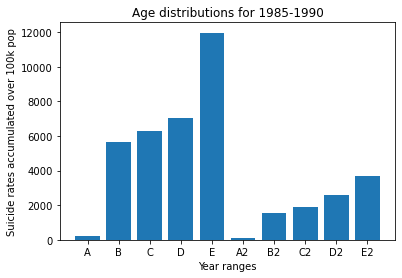

```python
plt.title('Age distributions for 1985-1990')
plt.xlabel("Year ranges")
plt.ylabel("Suicide rates accumulated over 100k pop")
plt.bar(categories,rates_1985)
```

```
<BarContainer object of 10 artists>
```

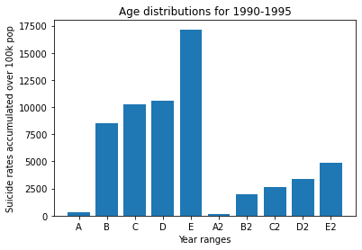

```python
plt.title('Age distributions for 1990-1995')
plt.xlabel("Year ranges")
plt.ylabel("Suicide rates accumulated over 100k pop")
plt.bar(categories,rates_1990)
```

```
<BarContainer object of 10 artists>
```

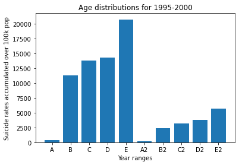

```python
plt.title('Age distributions for 1995-2000')
plt.xlabel("Year ranges")
plt.ylabel("Suicide rates accumulated over 100k pop")
plt.bar(categories,rates_1995)
```

```
<BarContainer object of 10 artists>
```

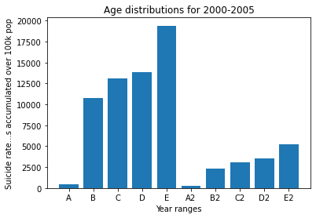

```python
plt.title('Age distributions for 2000-2005')
plt.xlabel("Year ranges")
plt.ylabel("Suicide rate…s accumulated over 100k pop")
plt.bar(categories,rates_2000)
```

```
<BarContainer object of 10 artists>
```

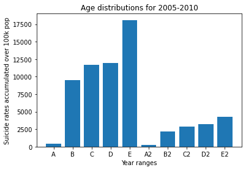

```python
plt.title('Age distributions for 2005-2010')
plt.xlabel("Year ranges")
plt.ylabel("Suicide rates accumulated over 100k pop")
plt.bar(categories,rates_2005)
```

```
<BarContainer object of 10 artists>
```

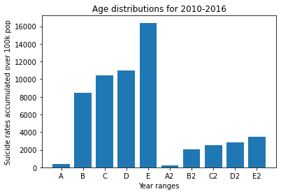

```python
plt.title('Age distributions for 2010-2016')
plt.xlabel("Year ranges")
plt.ylabel("Suicide rates accumulated over 100k pop")
plt.bar(categories,rates_2010)
```

```python
####Step 4 - Analysis Part 3: GDP vs. Suicide Rate
```

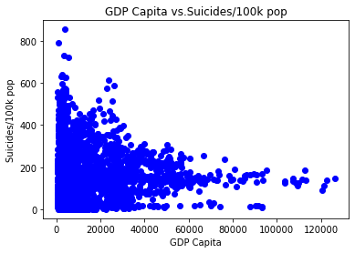

```python
gdp_dict = dict()
for row in suicide_df.itertuples(index=False): # go through each row of the dataframe, ignore the leftmost column known as index
    gdp = row[9]
    s_rate = row[6]
    if gdp in gdp_dict.keys():
        gdp_dict[gdp] += s_rate
    else:
        gdp_dict[gdp] = s_rate

gdp_vals = []
gdp_rates=  []
for i in gdp_dict.keys():
    gdp_vals.append(i)
    gdp_rates.append(gdp_dict[i])

plt.scatter(gdp_vals,gdp_rates,color = "blue")
# naming the axis labels
plt.title("GDP Capita vs.Suicides/100k pop")
plt.xlabel("GDP Capita")
plt.ylabel("Suicides/100k pop")
#display the graph
plt.show()
```

### Works Cited:

```
Hoffman, C. (n.d.). What is a csv file, and how do i open it? How-To Geek. Retrieved December 15, 2022, from https://www.howtogeek.com/348960/what-is-a-csv-file-and-how-do-i-open-it/
Suicide and suicidal thoughts—Symptoms and causes. (July 2022). Mayo Clinic. Retrieved December 15, 2022, from https://www.mayoclinic.org/diseases-conditions/suicide/symptoms-causes/syc-20378048
```